# Configurar el ambiente de desarrollo y crear el proyecto

Antes de comenzar a programar debes configurar el ambiente de desarrollo, esto es, instalar las herramientas necesarias para poder programar en Java.

## Descarga de aplicaciones

### JDK (Java Development Kit)

**JDK (Java Development Kit)**: es un paquete con programas para compilar, interpretar y ejecutar el código java así como también un compendio de código prediseñado para facilitar la creación de aplicaciones java. Contiene:

1. *JRE (Java Runtime Environment)*: es el conjunto de programas y librerías necesarias para ejecutar las aplicaciones java, este programa se puede instalar de manera independiente y es posible que ya lo tengas en tu computadora.
2. *Javac (Java compiler)*: es el programa encargado de compilar el código java y pasarlo a bytecode, que es el lenguaje que interpreta la máquina virtual de java *JVM (Java Virtual Machine)* que es parte de JRE.
3. *Java Archive Tool*: es el programa encargado de ensamblar en un paquete las clases java compiladas en un programa ejecutable llamado JAR.

> Recurso: link de descargar de [JDK11 (Java SE Development Kit 11.0.19)](https://www.oracle.com/ar/java/technologies/javase/jdk11-archive-downloads.html)

Descarga la versión de Oracle JDK específica para tu plataforma y recuerda seguir las instrucciones de instalación. Es importante que configures la variable *PATH* como se indica en la sección *Setting the PATH Environment Variable*, también puedes leer [How do I set or change the PATH system variable?](https://www.java.com/download/help/path.html)

Una vez instalado JDK y configurada la variable de entorno PATH puedes probar la instalación ejecutando en una terminal, cmd (windows) o bash (linux), los comandos `java -version` y `javac -version`, de a uno a la vez, con un espacio luego de java y un guión junto a version. Deberías ver algo parecido a lo siguiente:

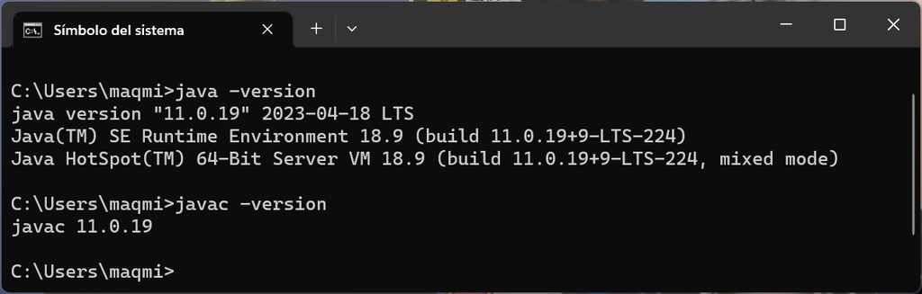

### IntelliJ IDEA

**IntelliJ IDEA**: es un programa conocido como *IDE (Integrated Development Environment)* el cual contiene herramientas útiles para programar tales como un editor de código, un explorador de archivos, un depurador de código, plugins para trabajar con sistemas de versionado como git,un compilador y ejecutor de código y visor de base de datos, entre otras. La idea de estos programas es que como desarrollador no tengas que usar ningún otro programa para trabajar.

> Recurso: link de descarga de [IntelliJ IDEA](https://www.jetbrains.com/idea/download/?section=windows#section=windows)

Recuerda seleccionar la versión community que es gratis aunque carece de algunas características que tiene la versión de pago.

### Gradle

**Gradle**: es una herramienta que permite la automatización de compilación de código abierto, la cual se encuentra centrada en la flexibilidad y el rendimiento. Los scripts de compilación de Gradle se escriben utilizando *Groovy* o *Kotlin DSL (Domain Specific Language)*.

Gradle tiene una gran flexibilidad y nos deja hacer usos otros lenguajes y no solo de Java. También cuenta con un sistema de gestión de dependencias muy estable.

Gradle es altamente personalizable y rápido, ya que completa las tareas de forma rápida y precisa reutilizando las salidas de las ejecuciones anteriores, sólo procesa las entradas que presentan cambios en paralelo. Además es el sistema de compilación oficial para Android y cuenta con soporte para diversas tecnologías y lenguajes.

> Recurso: link de descarga de [Gradle](https://gradle.org/next-steps/?version=8.0.2&format=all)

Después de descargar el Zip ponerlo en la misma carpeta que el JDK. Realizar el mismo proceso de las variables de entorno. Para mas información visitar la documentación oficial de Gradle en [gradle.org/install](https://gradle.org/install/).

## Crear el proyecto gradle e importarlo a IntelliJ IDEA

Para crear el proyecto utilizarás la herramienta [Spring Initializr](https://start.spring.io/), con ella se crean los archivos básicos necesarios, así como la estructura de directorios recomendada para comenzar a trabajar en una aplicación de Java, que utilice el [Spring Framework](https://spring.io/projects/spring-framework) implementado con [Spring Boot](https://spring.io/projects/spring-boot).

- **Framework**: en programación, un framework es un marco de trabajo que tiene como objetivo facilitar la solución de problemas que pueden surgir al programar. Los frameworks aceleran el proceso de programar facilitando tareas como la organización del código o el trabajo en equipo dentro de un proyecto. [Fuente](https://assemblerinstitute.com/blog/framework-programacion/#:~:text=En%20programaci%C3%B3n%2C%20un%20framework%20es,de%20un%20proyecto%2C%20por%20ejemplo.).
- **Spring framework**: es un framework para backend que se puede usar con Java, Kotlin y Groovy, Spring framework existe para facilitar la creación de aplicaciones, simplificando la estructura del proyecto y mejorando la velocidad de una aplicación empresarial. *Una aplicación empresarial* es una gran aplicación con fines comerciales, que será usada por muchas personas. Una aplicación empresarial es compleja de hacer, debe ser escalable (dar la posibilidad de ser modificada sin generarle pesadillas a los encargados de mantenerla), brindarle comodidad y seguridad al usuario. [Fuente](https://blog.codmind.com/que-es-spring).
- **Spring Boot**: Spring Boot funciona con Spring core (Spring framework). Spring Boot es una variación de Spring que viene con la configuración, que anteriormente, se tenía que hacer a mano, facilitando mucho el desarrollo con Spring, permitiendo al programador no tener que configurar nada, solo programar. [Fuente](https://blog.codmind.com/que-es-spring).
- **Spring Initializr**: es una herramienta web intuitiva que nos permite autogenerar el esqueleto de la aplicación. El inicializador genera el `pom.xml` o `build.gradle`, el `main` de la aplicación, y un test que comprueba que la aplicación arranca correctamente. [Fuente](https://blog.codmind.com/que-es-spring-boot/).